# The Slow March to Artistic Parity

Examining gender inequality in the Tate Collection

Mark Russeff

March 21, 2019

```r
# Course: BUAN 5210
# Title: The Slow March to Artistic Parity
# Purpose: Technical Appendix Final
# Date: March 14, 2019
# Authors: Mark Russeff
```

```r
#Load Packages
library(tidyverse)
library(GGally)
library(kableExtra)
library(ggplot2)
library(gridExtra)
library(grid)
library(gtable)
library(scales)
```

# 1 Load and Review Data

```r
#Artists data containing gender and other characteristics
artists <- read.csv('Artists.csv')

#Tate artwork data
tate <- read.csv('tate_artworks.csv')

#MOMA artwork data
moma <- read.csv('moma_artworks.csv')

#Check structure of the data
str(artists)
```

```
## 'data.frame':    15872 obs. of  10 variables:
##  $ X            : int  1 2 3 4 5 6 7 8 9 10 ...
##  $ ConstituentID: int  1 2 3 4 5 6 7 9 10 11 ...
##  $ DisplayName  : Factor w/ 15812 levels "…XYZ Dot Dot Dot Ex Why Zed Design, Ltd.",..: 12601 3438 1653 2278 11668 2920 1654 2969 6471 7000 ...
##  $ ArtistBio    : Factor w/ 7211 levels "","[Collective]",..: 1144 6633 1461 1466 3457 5500 1461 1783 1649 4476 ...
##  $ Nationality  : Factor w/ 131 levels "","Afghan","Albanian",..: 5 112 5 5 37 62 5 5 5 46 ...
##  $ Gender       : Factor w/ 4 levels "","Female","male",..: 4 4 4 4 4 4 4 4 2 4 ...
##  $ BeginDate    : int  1930 1936 1941 1946 1941 1925 1941 1923 1918 1886 ...
##  $ EndDate      : int  1992 0 0 0 0 0 0 0 0 1966 ...
##  $ Wiki.QID     : Factor w/ 3279 levels "","Q1000203",..: 1 1 1 31 1 1 1 2115 828 405 ...
##  $ ULAN         : int  NA NA NA 500027998 NA NA NA 500003363 500042413 500031000 ...
```

```r
str(tate)
```

```
## 'data.frame':    69201 obs. of  21 variables:
##  $ X                 : int  1 2 3 4 5 6 7 8 9 10 ...
##  $ id                : int  1035 1036 1037 1038 1039 1040 1041 1042 1043 1044 ...
##  $ accession_number  : Factor w/ 69201 levels "A00001","A00002",..: 1 2 3 4 5 6 7 8 9 10 ...
##  $ artist            : Factor w/ 3336 levels "?British School",..: 279 279 279 279 280 280 280 280 280 280 ...
##  $ artistRole        : Factor w/ 19 levels "after","and a pupil",..: 6 6 6 6 6 6 6 6 6 6 ...
##  $ artistId          : int  38 38 38 38 39 39 39 39 39 39 ...
##  $ title             : Factor w/ 43531 levels "-12°","! 1971",..: 3118 39039 36046 29909 34162 10024 33667 36685 36625 35949 ...
##  $ dateText          : Factor w/ 2736 levels "? exhibited 1805",..: 2474 2474 144 2474 514 514 514 514 514 514 ...
##  $ medium            : Factor w/ 3414 levels "","10 photo-etchings on paper",..: 3212 1284 1296 1284 1667 1667 1667 1667 1667 1667 ...
##  $ creditLine        : Factor w/ 3246 levels "","[uncovered during remounting of T03043] 1980",..: 1403 1403 1403 1403 3207 3207 3207 3207 3207 3207 ...
##  $ year              : Factor w/ 363 levels "","1545","1557",..: 1 1 134 1 175 175 175 175 175 175 ...
##  $ acquisitionYear   : int  1922 1922 1922 1922 1919 1919 1919 1919 1919 1919 ...
##  $ dimensions        : Factor w/ 25601 levels "","10.5ft x 20 x 10 -overall display dimensions -variable",..: 20554 19399 19923 19515 3606 3567 3598 3642 3584 3607 ...
##  $ width             : Factor w/ 1979 levels "","(1):","(diameter):",..: 1280 1140 1201 1158 927 909 919 949 913 927 ...
##  $ height            : Factor w/ 2076 levels "","100","1000",..: 1326 750 1414 1283 1140 1147 1138 1153 1140 1153 ...
##  $ depth             : num  NA NA NA NA NA NA NA NA NA NA ...
##  $ units             : Factor w/ 2 levels "","mm": 2 2 2 2 2 2 2 2 2 2 ...
##  $ inscription       : Factor w/ 2 levels "","date inscribed": 1 1 1 1 1 1 1 1 1 1 ...
##  $ thumbnailCopyright: Factor w/ 1222 levels ""," © Tate/ Original work by Liam Gillick",..: 1 1 1 1 1 1 1 1 1 1 ...
##  $ thumbnailUrl      : Factor w/ 58416 levels "","http://www.tate.org.uk/art/images/work/A/A00/A00001_8.jpg",..: 2 3 4 5 6 7 8 9 10 11 ...
##  $ url               : Factor w/ 69201 levels "http://www.tate.org.uk/art/artworks/abakanowicz-abakan-orange-t12980",..: 2409 2620 2583 2525 2549 2431 2540 2593 2589 2580 ...
```

## 1.1 Join the Data Sets

```r
#Reorder artists names structure in Tate to joind with MOMA artist information
splits <- str_split_fixed(tate$artist, ", ", 2)
tate$artist <- paste(splits[,2], splits[,1], sep = ' ')

#Join data sets
tate <- inner_join(tate, artists, by = c("artist" = "DisplayName"))

#Join MOMA data sets
moma <- inner_join(moma, artists, by = c("Artist" = "DisplayName")) %>%
  mutate(Gender = Gender.y) %>%
  filter(Gender %in% c("Male", "Female"))
```

## 1.2 Clean and Organize the Joined Data.

```r
#Select only variables of interest
tate <- tate %>%
  select(artist, title, dateText, medium, year, acquisitionYear, Nationality, Gender, BeginDate, EndDate)

#General data cleaning
tate <- tate %>%
  filter(Gender %in% c("Male", "Female")) %>%
  droplevels() %>%
  mutate(year = as.numeric(as.character(year))) %>%
  drop_na(Nationality, acquisitionYear, year)

#Create new variables of interest
#Subject of the work based on title searching
tate <- tate %>%
  mutate(subject = if_else(grepl("Women |women |Woman |woman |Girl |girl |Queen |Princess |Mrs | she | hers ", title) == TRUE, "Woman", if_else(grepl(" Men | ^Men| men | Man | ^Man | man | Boy | ^Boy | boy | King | ^King | Prince | Mr |^Mr | he | his | him ", title) == TRUE, "Man", "Unknown"))) %>%
  mutate(subject = as.factor(subject))

#Create decade, artist age and age of art variables
tate <- tate %>%
  mutate(decade = acquisitionYear - (acquisitionYear %% 10)) %>%
  mutate(age = if_else(BeginDate == 0, 0,
        if_else(EndDate == 0, 2019 - BeginDate, as.double(EndDate - BeginDate)))) %>%
  mutate(artAge = if_else((acquisitionYear - year) > 0, acquisitionYear - year, 0))
```

# 2 Univariate non-graphical

## 2.1 Categorical data - summary

```r
# Inspect descriptive statistics of data
summary(tate)
```

```
##     artist                        title         dateText
##  Length:12002       [no title]       :1400   1972   :  377
##  Class :character   Untitled         : 440   1971   :  347
##  Mode  :character   [title not known]: 173   1970   :  326
##                     Walking the Dog  :  41   1973   :  273
##                     Gardeners        :  40   2001   :  258
##                     Memory           :  39   1998   :  248
##                     (Other)          :9869   (Other):10173
##                                        medium          year
##  Screenprint on paper                     :1773   Min.   :1700
##  Lithograph on paper                      :1217   1st Qu.:1965
##  Etching on paper                         : 880   Median :1976
##  Oil paint on canvas                      : 734   Mean   :1973
##  Photograph, gelatin silver print on paper: 498   3rd Qu.:1991
##  Print on paper                           : 381   Max.   :2012
##  (Other)                                  :6519
##  acquisitionYear    Nationality      Gender        BeginDate
##  Min.   :1869    British  :5333   Female: 1159   Min.   :   0
##  1st Qu.:1976    American :2837   Male  :10843   1st Qu.:1912
##  Median :1994    German   :1423                  Median :1930
##  Mean   :1990    French   : 458                  Mean   :1849
##  3rd Qu.:2007    Argentine: 212                  3rd Qu.:1944
##  Max.   :2013    Japanese : 162                  Max.   :1982
##                  (Other)  :1577
##     EndDate        subject          decade          age
##  Min.   :   0   Man    :   81   Min.   :1860   Min.   :  0.00
##  1st Qu.:   0   Unknown:11761   1st Qu.:1970   1st Qu.: 61.00
##  Median :1945   Woman  :  160   Median :1990   Median : 74.00
##  Mean   :1089                   Mean   :1985   Mean   : 69.74
##  3rd Qu.:1992                   3rd Qu.:2000   3rd Qu.: 84.00
##  Max.   :2019                   Max.   :2010   Max.   :109.00
##
##      artAge
##  Min.   :  0.0
##  1st Qu.:  2.0
##  Median :  9.0
##  Mean   : 17.2
##  3rd Qu.: 28.0
##  Max.   :278.0
##
```

**Observations on the data**

- There are 10x more works by male artists in the Tate Collection than women.
- Twice as many pieces of art have women as the subject than men.
- The Tate has been acquiring art for a very long time, since 1869.
- The data set we have only has acquisitions up until 2013.
- The median art age, time between the art being made and acquired is only 9 years.
- The Tate Collection has more screenprints on paper than any other medium.
- Naturally most of the art is British but there is a very large portion that is American & German.

## 2.2 Categorical data - tabulation

### 2.2.1 Gender

```r
#Table of data by gender of artist
tate %>%
  group_by(Gender) %>%
  summarise(count = n(),
            median_year = median(year),
            median_acqYear = median(acquisitionYear),
            median_artAge = median(artAge)) %>%
  kable() %>%
  kable_styling(bootstrap_options = c("striped", "hover", "condensed", "responsive"))
```

| Gender | count | median_year | median_acqYear | median_artAge |
| --- | --- | --- | --- | --- |
| Female | 1159 | 1991 | 2002 | 6 |
| Male | 10843 | 1975 | 1991 | 9 |

- The median year for art created by a male artists is older, this is because art is historically male dominated.
- The median acquisition year for female artists is 2002 while male artists is 1991, suggesting possible progress as the collection is acquiring more female artist’s works in the 2000’s.
- Womens art is being acquired sooner on average than men, at only 6 years after its made.

### 2.2.2 Gender and Subject Matter

```r
tate %>%
  group_by(Gender, subject) %>%
  summarise(count = n(),
            median_year = median(year),
            median_acqYear = median(acquisitionYear),
            median_artAge = median(artAge)) %>%
  arrange(desc(count)) %>%
  kable() %>%
  kable_styling(bootstrap_options = c("striped", "hover", "condensed", "responsive"))
```

| Gender | subject | count | median_year | median_acqYear | median_artAge |
| --- | --- | --- | --- | --- | --- |
| Male | Unknown | 10641 | 1975.0 | 1991 | 9.0 |
| Female | Unknown | 1120 | 1991.0 | 2002 | 5.0 |
| Male | Woman | 132 | 1950.0 | 1979 | 28.0 |
| Male | Man | 70 | 1975.5 | 1996 | 21.5 |
| Female | Woman | 28 | 1965.5 | 2009 | 41.0 |
| Female | Man | 11 | 1967.0 | 2009 | 42.0 |

- Women are the subject of art more than men.
- More Male artists are using Women as their subjects than Women.

### 2.2.3 Female Artists by Decade

```r
#Table of data for female artists by decade
tate %>%
  filter(Gender == "Female") %>%
  group_by(Gender, decade) %>%
  summarise(count = n(),
            median_year = median(year),
            median_acqYear = median(acquisitionYear),
            median_artAge = median(artAge)) %>%
  kable() %>%
  kable_styling(bootstrap_options = c("striped", "hover", "condensed", "responsive"))
```

| Gender | decade | count | median_year | median_acqYear | median_artAge |
| --- | --- | --- | --- | --- | --- |
| Female | 1910 | 2 | 1909.0 | 1917 | 8.0 |
| Female | 1920 | 3 | 1920.0 | 1925 | 4.0 |
| Female | 1930 | 4 | 1924.5 | 1935 | 9.5 |
| Female | 1940 | 11 | 1915.0 | 1940 | 25.0 |
| Female | 1950 | 6 | 1950.5 | 1957 | 5.5 |
| Female | 1960 | 17 | 1959.0 | 1965 | 3.0 |
| Female | 1970 | 51 | 1965.0 | 1975 | 5.0 |
| Female | 1980 | 113 | 1979.0 | 1984 | 4.0 |
| Female | 1990 | 255 | 1994.0 | 1997 | 2.0 |
| Female | 2000 | 546 | 1995.0 | 2004 | 10.0 |
| Female | 2010 | 151 | 1997.0 | 2012 | 14.0 |

### 2.2.4 Female Artists by Medium

```r
tate %>%
  filter(Gender == "Female") %>%
  group_by(Gender, medium) %>%
  summarise(count = n(),
            median_year = median(year),
            median_acqYear = median(acquisitionYear),
            median_artAge = median(artAge)) %>%
  arrange(desc(count)) %>%
  head(n = 10) %>%
  kable() %>%
  kable_styling(bootstrap_options = c("striped", "hover", "condensed", "responsive"))
```

| Gender | medium | count | median_year | median_acqYear | median_artAge |
| --- | --- | --- | --- | --- | --- |
| Female | Lithograph on paper | 160 | 1992.0 | 1998 | 4 |
| Female | Photograph, gelatine silver print on paper | 84 | 1967.0 | 2009 | 42 |
| Female | Oil paint on canvas | 69 | 1958.0 | 1994 | 15 |
| Female | Photograph, gelatin silver print on paper | 67 | 1976.0 | 2002 | 25 |
| Female | Etching on paper | 51 | 1991.0 | 1997 | 3 |
| Female | Screenprint on paper | 43 | 1996.0 | 1996 | 1 |
| Female | Etching and aquatint on paper | 30 | 1992.5 | 1997 | 8 |
| Female | Digital print on paper | 28 | 2001.0 | 2002 | 2 |
| Female | Ink on paper | 27 | 1988.0 | 1996 | 1 |
| Female | Photo-etching on paper | 25 | 2001.0 | 2002 | 1 |

- Lithographs on paper by Female artists are popular.
- The Tate has been acquiring more photographs by Female artists, but they are primarily older works from the 1960’s and 1970’s.

### 2.2.5 Female Artists by Nationality

```r
tate %>%
  filter(Gender == "Female") %>%
  group_by(Gender, Nationality) %>%
  summarise(count = n(),
            median_year = median(year),
            median_acqYear = median(acquisitionYear),
            median_artAge = median(artAge)) %>%
  arrange(desc(count)) %>%
  head(n = 10) %>%
  kable() %>%
  kable_styling(bootstrap_options = c("striped", "hover", "condensed", "responsive"))
```

| Gender | Nationality | count | median_year | median_acqYear | median_artAge |
| --- | --- | --- | --- | --- | --- |
| Female | American | 511 | 1985.0 | 2004.0 | 10.0 |
| Female | British | 341 | 1994.0 | 1998.0 | 3.0 |
| Female | German | 90 | 1975.0 | 2003.5 | 23.5 |
| Female | Portuguese | 45 | 1996.0 | 1997.0 | 1.0 |
| Female | Australian | 34 | 1997.0 | 1998.0 | 1.0 |
| Female | French | 29 | 1951.0 | 1990.0 | 36.0 |
| Female | Brazilian | 12 | 1964.5 | 2013.0 | 45.5 |
| Female | Scottish | 10 | 2009.5 | 2012.0 | 2.5 |
| Female | South African | 10 | 1996.0 | 1996.0 | 0.0 |
| Female | Swedish | 9 | 1970.0 | 1991.0 | 19.0 |

- The Tate Collection, which is British, has more Female American artists than British.
- They have been building their collection of American Female artists recently.

### 2.2.6 Male Artists by Nationality

```r
tate %>%
  filter(Gender == "Male") %>%
  group_by(Gender, Nationality) %>%
  summarise(count = n(),
            median_year = median(year),
            median_acqYear = median(acquisitionYear),
            median_artAge = median(artAge)) %>%
  arrange(desc(count)) %>%
  head(n = 10) %>%
  kable() %>%
  kable_styling(bootstrap_options = c("striped", "hover", "condensed", "responsive"))
```

| Gender | Nationality | count | median_year | median_acqYear | median_artAge |
| --- | --- | --- | --- | --- | --- |
| Male | British | 4992 | 1973.0 | 1981 | 6 |
| Male | American | 2326 | 1977.0 | 1996 | 12 |
| Male | German | 1333 | 1982.0 | 2007 | 18 |
| Male | French | 429 | 1923.0 | 1974 | 39 |
| Male | Argentine | 211 | 1981.0 | 2009 | 27 |
| Male | Japanese | 160 | 1972.0 | 2012 | 40 |
| Male | Italian | 153 | 1972.0 | 1983 | 7 |
| Male | Spanish | 148 | 1939.5 | 1972 | 33 |
| Male | Swiss | 137 | 1971.0 | 1979 | 7 |
| Male | Lebanese | 120 | 2007.0 | 2008 | 1 |

- There are twice as many pieces by Male British artists that American ones.
- Like the women, they are acquiring more Americans recently (higher median acquisition year)

# 3 Univariate graphical: categorical

## 3.1 Gender

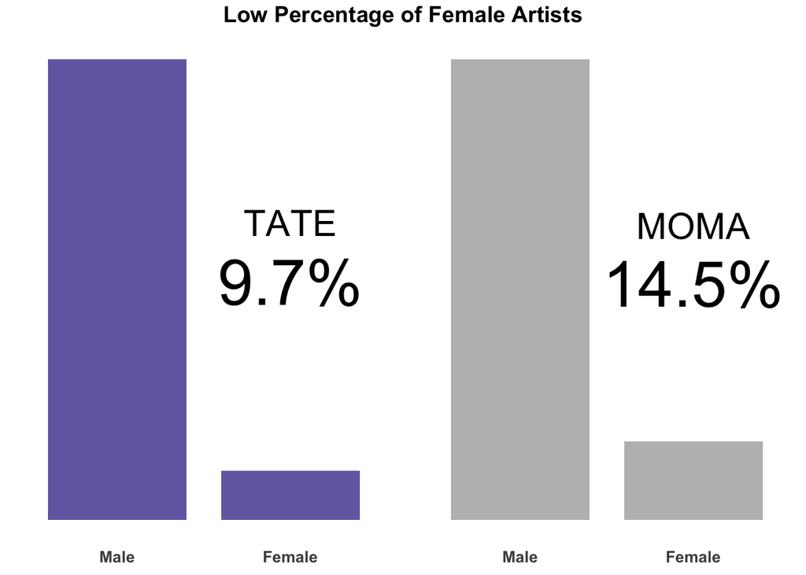

```r
#Graph gender distributions for both Tate and MOMA
tate_g1 <- grid.arrange(
  #Graph the Tates collections by artists gender.
  tate %>%
    group_by(Gender) %>%
    summarise(count = n(), sum = sum(n())) %>%
    ggplot(aes(x = reorder(Gender, -count),
             y = count)) +
    geom_bar(stat = "identity", fill = "#756bb1",
             width = 0.8) +
    theme(panel.grid.major = element_blank(),
        panel.grid.minor = element_blank()) +
    annotate("text", x = 2, y = 5600, label = "9.7%", size = 14) +
    annotate("text", x = 2, y = 7000, label = "TATE", size = 8) +
    theme_classic() +
    theme(axis.text = element_text(face = "bold", size = 10),
        axis.text.y = element_blank(),
        axis.title = element_blank(),
        axis.ticks = element_blank(),
        axis.line = element_blank(),
        plot.title = element_text(size = 12, hjust = 0.12, vjust = -1),
        legend.title = element_text(face = "bold")) ,

  #Graph MOMA's collection by artists gender for comparison
  moma %>%
    group_by(Gender) %>%
    summarise(count = n()) %>%
    ggplot(aes(x = reorder(Gender, -count),
             y = count)) +
    geom_bar(stat = "identity", fill = "#bdbdbd",
             width = 0.8) +
    theme(panel.grid.major = element_blank(),
        panel.grid.minor = element_blank()) +
    annotate("text", x = 2, y = 53000, label = "14.5%", size = 14) +
    annotate("text", x = 2, y = 66000, label = "MOMA", size = 8) +
    theme_classic() +
    theme(axis.text = element_text(face = "bold", size = 10),
        axis.text.y = element_blank(),
        axis.title = element_blank(),
        axis.ticks = element_blank(),
        axis.line = element_blank(),
        plot.title = element_text(size = 12, hjust = 0.12, vjust = -1),
        legend.title = element_text(face = "bold")) ,

ncol = 2,
top = textGrob(
    "Low Percentage of Female Artists",
    gp = gpar(fontface = "bold", fontsize = 14))
)
```

```r
tate_g1
```

```r
#Save graph
ggsave("tate_g1.png", plot = tate_g1)
```

- The Tate appears to have a lower percentage of Female artists than MOMA.
- Is the Tate falling behind?
- MOMA does have a much larger collection with less older works of art.

## 3.2 Gender after 1990

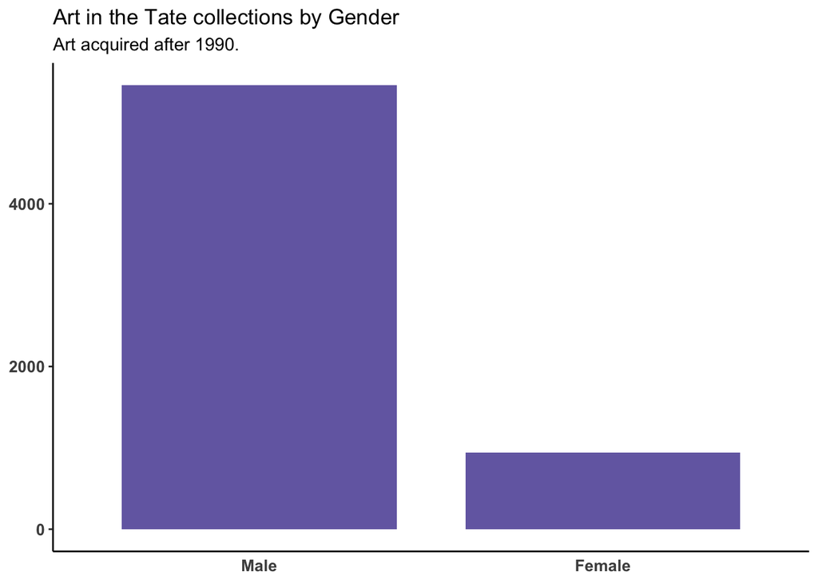

```r
#Graph gender gap after 1990

tate %>%
    filter(acquisitionYear > 1990) %>%
    group_by(Gender) %>%
    summarise(count = n()) %>%
    ggplot(aes(x = reorder(Gender, -count),
             y = count)) +
    geom_bar(stat = "identity", fill = "#756bb1",
             width = 0.8) +
    theme(panel.grid.major = element_blank(),
        panel.grid.minor = element_blank()) +
    ggtitle("Art in the Tate collections by Gender",
          subtitle = "Art acquired after 1990.") +
    theme_classic() +
    theme(axis.text = element_text(face = "bold", size = 10),
        axis.title = element_blank(),
        axis.ticks.x = element_blank(),
        legend.title = element_text(face = "bold"))
```

- Gender gap looks slightly better after 1990 but there is still a large gap in acquisitions between Men & Women.

## 3.3 Gender and Subject Matter.

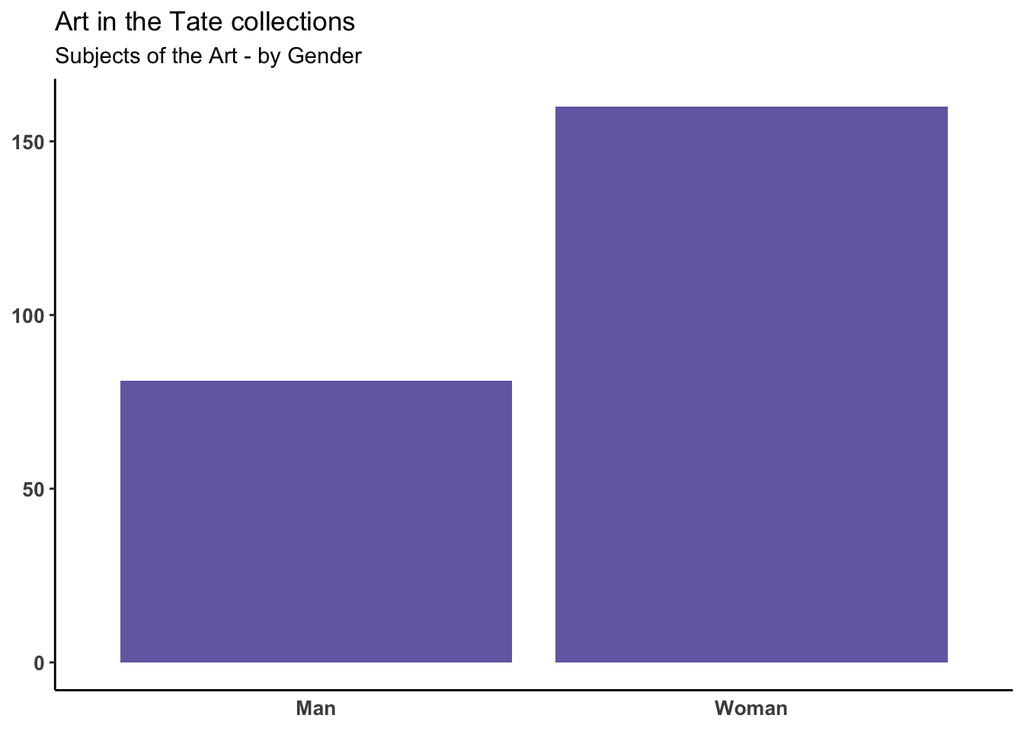

```r
#Graph subject matter based on keywords from titles.
tate %>%
  filter(subject != "Unknown") %>%
  group_by(subject) %>%
  summarise(count = n()) %>%
  ggplot(aes(x = subject, y = count)) +
  geom_bar(stat = "identity", fill = "#756bb1") +
  theme(panel.grid.major = element_blank(),
      panel.grid.minor = element_blank()) +
  ggtitle("Art in the Tate collections",
        subtitle = "Subjects of the Art - by Gender") +
  theme_classic() +
  theme(axis.text = element_text(face = "bold", size = 10),
      axis.title = element_blank(),
      axis.ticks.x = element_blank(),
      legend.title = element_text(face = "bold"))
```

- Based on a small sample size.
- Women are the subject of art more than men.

## 3.4 Nationality

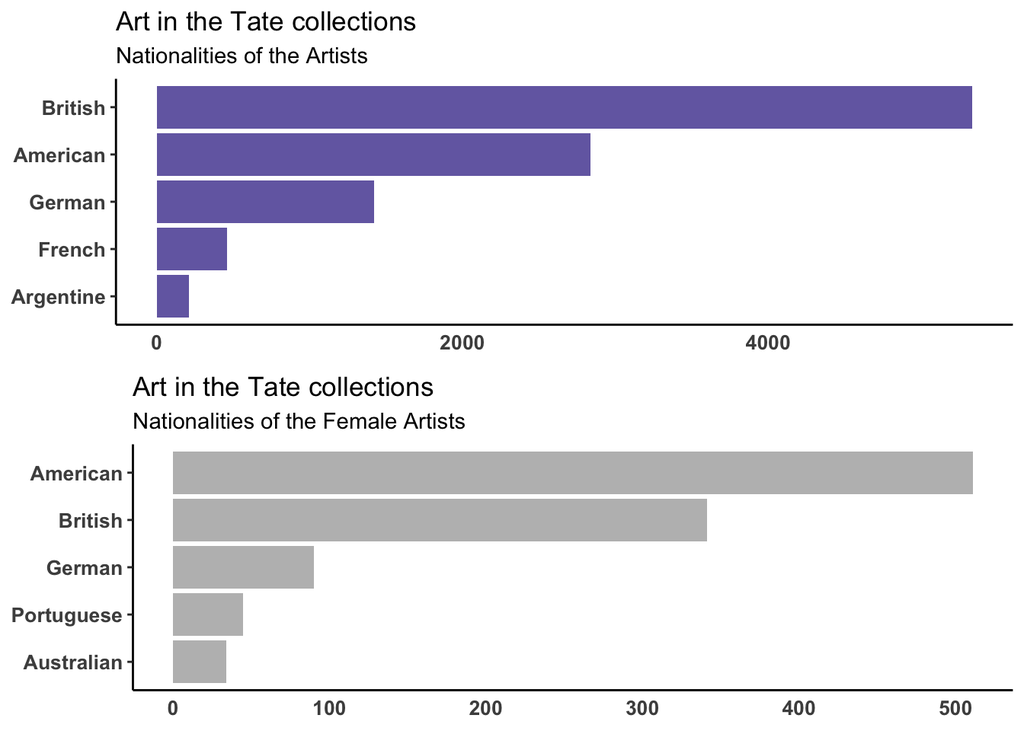

```r
grid.arrange(
#Graph the Tates collection top Nationalities.
 tate %>%
  group_by(Nationality) %>%
  summarise(count = n()) %>%
  arrange(desc(count)) %>%
  head(n = 5) %>%
  ggplot(aes(x = reorder(Nationality, count), y = count)) +
  geom_bar(stat = "identity", fill = "#756bb1") +
  theme(panel.grid.major = element_blank(),
      panel.grid.minor = element_blank()) +
  ggtitle("Art in the Tate collections",
        subtitle = "Nationalities of the Artists") +
  theme_classic() +
  coord_flip() +
  theme(axis.text = element_text(face = "bold", size = 10),
      axis.title = element_blank(),
      axis.ticks.x = element_blank(),
      legend.title = element_text(face = "bold")) ,

tate %>%
  filter(Gender == "Female") %>%
  group_by(Nationality) %>%
  summarise(count = n()) %>%
  arrange(desc(count)) %>%
  head(n = 5) %>%
  ggplot(aes(x = reorder(Nationality, count), y = count)) +
  geom_bar(stat = "identity", fill = "#bdbdbd") +
  theme(panel.grid.major = element_blank(),
      panel.grid.minor = element_blank()) +
  ggtitle("Art in the Tate collections",
        subtitle = "Nationalities of the Female Artists") +
  theme_classic() +
  coord_flip() +
  theme(axis.text = element_text(face = "bold", size = 10),
      axis.title = element_blank(),
      axis.ticks.x = element_blank(),
      legend.title = element_text(face = "bold")) ,

ncol = 1
)
```

- While the whole collection is predominately British artists, Female artists are predominately American.

# 4 Multi-variate graphical: quantitative

## 4.1 Correlations

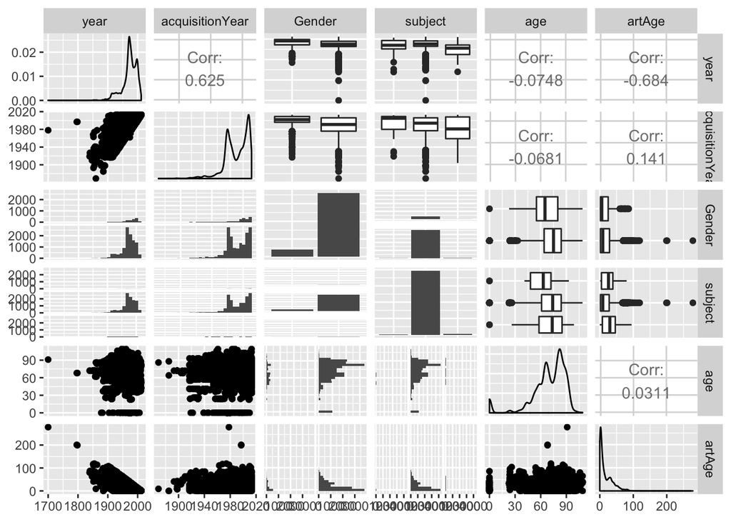

```r
#Correlations
ggpairs(subset(tate, select = -c(artist, title, dateText, medium, Nationality, decade, BeginDate, EndDate)))
```

- Not a whole lot of interest here, however we can see that the year an artwork is created is highly positively correlated to the acquisition year. This makes sense because of course art will be acquired after it has been made.

# 5 Multi-variate graphical: categorical and quantitative

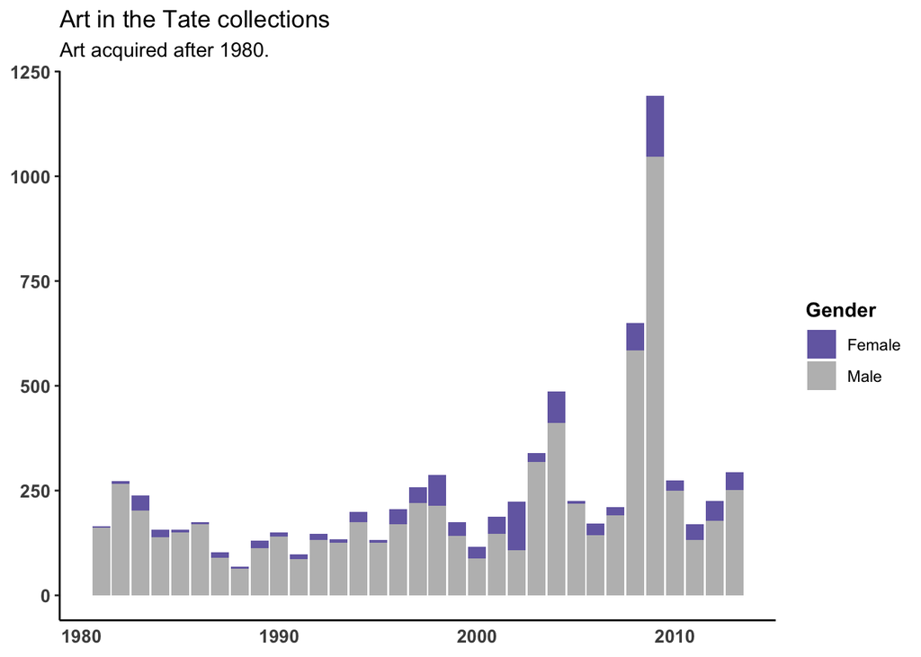

```r
#Graph to look at gender distributions of acquisitions per year since 1980
tate %>%
  filter(acquisitionYear > 1980) %>%
  group_by(acquisitionYear, Gender) %>%
  summarise(count = n()) %>%
  ggplot(aes(x = acquisitionYear, y = count, fill = Gender)) +
  geom_bar(stat = "identity") +
  theme(panel.grid.major = element_blank(),
      panel.grid.minor = element_blank()) +
  ggtitle("Art in the Tate collections",
        subtitle = "Art acquired after 1980.") +
  theme_classic() +
  scale_fill_manual(values = c("#756bb1","#bdbdbd")) +
  theme(axis.text = element_text(face = "bold", size = 10),
      axis.title = element_blank(),
      axis.ticks.x = element_blank(),
      legend.title = element_text(face = "bold"))
```

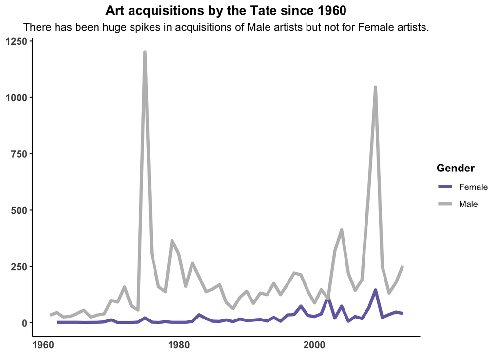

```r
#Line graph examining the same relationship as above.
tate_g3 <- tate %>%
  filter(acquisitionYear > 1960) %>%
  group_by(acquisitionYear, Gender) %>%
  summarise(count = n()) %>%
  ggplot(aes(x = acquisitionYear, y = count, color = Gender)) +
  geom_line(size = 1.5) +
  theme(panel.grid.major = element_blank(),
      panel.grid.minor = element_blank()) +
  ggtitle("Art acquisitions by the Tate since 1960",
        subtitle = "There has been huge spikes in acquisitions of Male artists but not for Female artists.") +
  theme_classic() +
  scale_colour_manual(values = c("#756bb1","#bdbdbd")) +
  theme(axis.text = element_text(face = "bold", size = 10),
      axis.title = element_blank(),
      axis.ticks.x = element_blank(),
      legend.title = element_text(face = "bold"),
      plot.title = element_text(hjust=0.5, face ="bold"),
      plot.subtitle = element_text(hjust = 0.5))

tate_g3
```

```r
ggsave("tate_g3.png", plot = tate_g3)
```

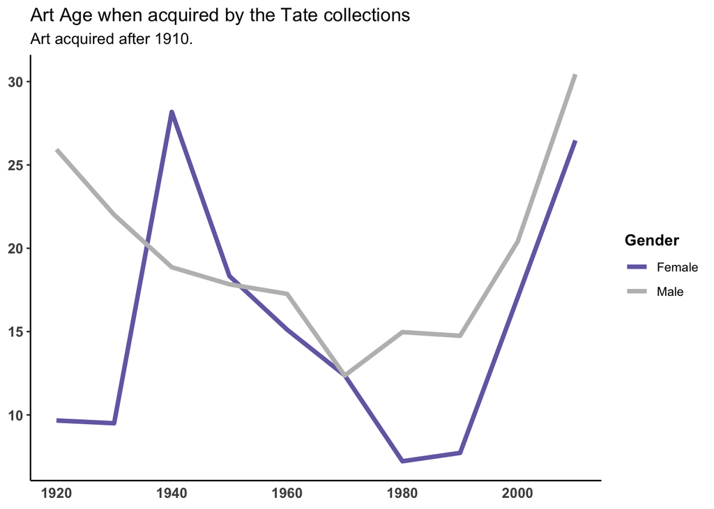

```r
#Graph looking at the age of art when it is acquired by the Tate.
tate %>%
  filter(decade > 1910) %>%
  group_by(decade, Gender) %>%
  summarise(meanAge = mean(artAge)) %>%
  ggplot(aes(x = decade, y = meanAge, color = Gender)) +
  geom_line(size =1.5) +
  theme(panel.grid.major = element_blank(),
      panel.grid.minor = element_blank()) +
  ggtitle("Art Age when acquired by the Tate collections",
        subtitle = "Art acquired after 1910.") +
  theme_classic() +
  scale_colour_manual(values = c("#756bb1","#bdbdbd")) +
  theme(axis.text = element_text(face = "bold", size = 10),
      axis.title = element_blank(),
      axis.ticks.x = element_blank(),
      legend.title = element_text(face = "bold"))
```

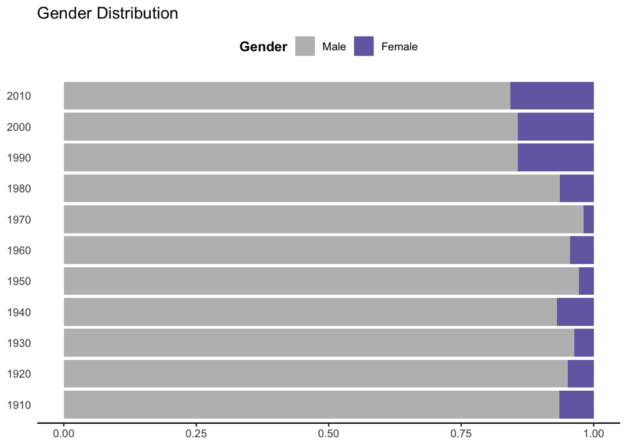

```r
#Graphing artist gender distribution since 1900.
tate %>%
  filter(decade > 1900) %>%
  group_by(decade, Gender) %>%
  summarise(subtotal = sum(n())) %>%
  group_by(decade) %>%
  mutate(gender_pct = subtotal / sum(subtotal)) %>%

  mutate(brand2 = factor(decade, levels = filter(., Gender == "Male") %>% .$decade)) %>%
  ggplot(aes(x = brand2, y = gender_pct, fill = Gender)) +
    geom_bar(stat = "identity") +
    labs(fill = "Gender") +
    coord_flip() +
    guides(fill = guide_legend(reverse = TRUE)) +
    theme_classic() +
    scale_fill_manual(values = c("#756bb1","#bdbdbd")) +
    theme(legend.position = "top",
          legend.justification = "center",
          legend.title = element_text(face = "bold"),
          axis.title.y = element_blank(),
          axis.ticks.y = element_blank(),
          axis.line.y = element_blank(),
          axis.title.x = element_blank()) +
    ggtitle("Gender Distribution")
```

- Recent decades appear to be acquiring a higher percentage of art by women.
- The overal numbers are still very low, no decade has eclipsed 25% of acquisitions of women artists.

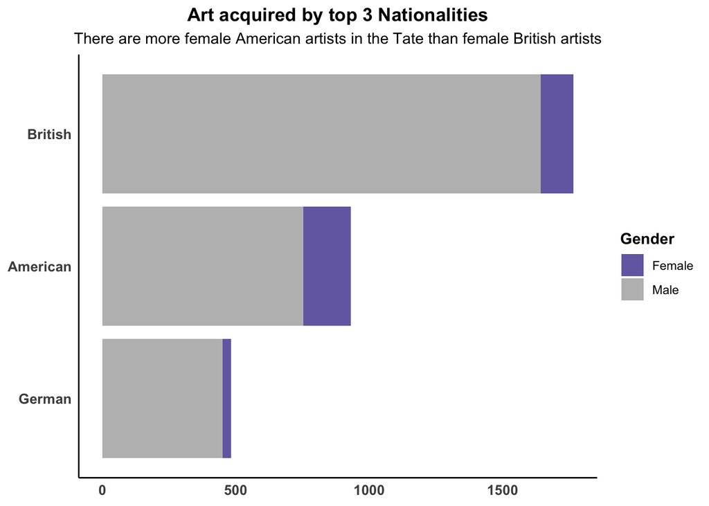

```r
#Graphing the top 3 Nationalities in the Tate collection.
tate_g4 <- tate %>%
  filter(Nationality == c("British", "American", "German")) %>%
  group_by(Nationality, Gender) %>%
  summarise(count = n()) %>%
  ggplot(aes(x = reorder(Nationality, count), y = count, fill = Gender)) +
  geom_bar(stat = "identity") +
  theme(panel.grid.major = element_blank(),
      panel.grid.minor = element_blank()) +
  ggtitle("Art acquired by top 3 Nationalities",
        subtitle = "There are more female American artists in the Tate than female British artists") +
  theme_classic() +
  scale_fill_manual(values = c("#756bb1","#bdbdbd")) +
  coord_flip() +
  theme(axis.text = element_text(face = "bold", size = 10),
      axis.title = element_blank(),
      axis.ticks = element_blank(),
      legend.title = element_text(face = "bold"),
      plot.title = element_text(hjust=0.5, face ="bold"),
        plot.subtitle = element_text(hjust = 0.5))
tate_g4
```

```r
ggsave("tate_g4.png", plot = tate_g4)
```

- The Tate has a lot of Female American artists in their collection.
- In fact, they have more American women then they do British.
- For the men, there are roughly trwice as many British artists as American.
- The Tate is a very British focused institution in general.

**Observations**

- We can see that the Tate has a very low percentage of thier artists are women.
- The ratio is not getting better very quickly, progress is slow.
- When we look at the subjects gender, then women are higher (small sample)
- So women are subjects in higher proportion to men but in dractically lower proportion as artists.

# 6 Research Question

## 6.1 Is the gender gap improving at the Tate?

```r
#Table of aquisitions by decade seperated by gender.
tate %>%
  filter(decade > 1910) %>%
  group_by(decade, Gender) %>%
  summarise(Count = n()) %>%
  arrange(desc(decade)) %>%
  kable() %>%
  kable_styling(bootstrap_options = c("striped", "hover", "condensed", "responsive"))
```

| decade | Gender | Count |
| --- | --- | --- |
| 2010 | Female | 151 |
| 2010 | Male | 812 |
| 2000 | Female | 546 |
| 2000 | Male | 3257 |
| 1990 | Female | 255 |
| 1990 | Male | 1529 |
| 1980 | Female | 113 |
| 1980 | Male | 1658 |
| 1970 | Female | 51 |
| 1970 | Male | 2656 |
| 1960 | Female | 17 |
| 1960 | Male | 367 |
| 1950 | Female | 6 |
| 1950 | Male | 208 |
| 1940 | Female | 11 |
| 1940 | Male | 147 |
| 1930 | Female | 4 |
| 1930 | Male | 105 |
| 1920 | Female | 3 |
| 1920 | Male | 58 |

**Null Hypothesis: Mean percentage of women artists is the same between every decade.**

```r
#Building a variable with mean percentage of women artists by decade to smooth out some of the volatility.
tate_hyp <- tate %>%
  group_by(decade, acquisitionYear, Gender) %>%
  summarise(count = n()) %>%
  transmute(Gender, percent = round(count/sum(count) * 100, 1)) %>%
  filter(Gender == "Female")

tate_hyp
```

```
## # A tibble: 67 x 4
## # Groups:   decade, acquisitionYear [67]
##    decade acquisitionYear Gender percent
##     <dbl>           <int> <fct>    <dbl>
##  1   1910            1917 Female    14.3
##  2   1920            1924 Female     9.1
##  3   1920            1925 Female    50
##  4   1920            1927 Female     7.1
##  5   1930            1932 Female    16.7
##  6   1930            1933 Female     6.7
##  7   1930            1937 Female    25
##  8   1930            1939 Female     5.3
##  9   1940            1940 Female    14.3
## 10   1940            1942 Female     6.7
## # ... with 57 more rows
```

```r
#Looking at mean percentage of Female art aquired by the Tate by Decade and testing if they are statistically different.
t.test(tate_hyp$percent[tate_hyp$decade == 2000], tate_hyp$percent[tate_hyp$decade == 2010])
```

```
##
##  Welch Two Sample t-test
##
## data:  tate_hyp$percent[tate_hyp$decade == 2000] and tate_hyp$percent[tate_hyp$decade == 2010]
## t = 0.081535, df = 11.603, p-value = 0.9364
## alternative hypothesis: true difference in means is not equal to 0
## 95 percent confidence interval:
##  -11.36266  12.24266
## sample estimates:
## mean of x mean of y
##     16.99     16.55
```

```r
t.test(tate_hyp$percent[tate_hyp$decade == 1980], tate_hyp$percent[tate_hyp$decade == 2010])
```

```
##
##  Welch Two Sample t-test
##
## data:  tate_hyp$percent[tate_hyp$decade == 1980] and tate_hyp$percent[tate_hyp$decade == 2010]
## t = -2.6139, df = 5.0516, p-value = 0.04698
## alternative hypothesis: true difference in means is not equal to 0
## 95 percent confidence interval:
##  -18.4377767  -0.1822233
## sample estimates:
## mean of x mean of y
##      7.24     16.55
```

```r
t.test(tate_hyp$percent[tate_hyp$decade == 1990], tate_hyp$percent[tate_hyp$decade == 2000])
```

```
##
##  Welch Two Sample t-test
##
## data:  tate_hyp$percent[tate_hyp$decade == 1990] and tate_hyp$percent[tate_hyp$decade == 2000]
## t = -0.84897, df = 12.67, p-value = 0.4117
## alternative hypothesis: true difference in means is not equal to 0
## 95 percent confidence interval:
##  -14.667478   6.407478
## sample estimates:
## mean of x mean of y
##     12.86     16.99
```

```r
t.test(tate_hyp$percent[tate_hyp$decade == 1980], tate_hyp$percent[tate_hyp$decade == 1990])
```

```
##
##  Welch Two Sample t-test
##
## data:  tate_hyp$percent[tate_hyp$decade == 1980] and tate_hyp$percent[tate_hyp$decade == 1990]
## t = -2.0901, df = 17.603, p-value = 0.05141
## alternative hypothesis: true difference in means is not equal to 0
## 95 percent confidence interval:
##  -11.27828215   0.03828215
## sample estimates:
## mean of x mean of y
##      7.24     12.86
```

```r
t.test(tate_hyp$percent[tate_hyp$decade == 1970], tate_hyp$percent[tate_hyp$decade == 1980])
```

```
##
##  Welch Two Sample t-test
##
## data:  tate_hyp$percent[tate_hyp$decade == 1970] and tate_hyp$percent[tate_hyp$decade == 1980]
## t = -2.0324, df = 15.51, p-value = 0.05961
## alternative hypothesis: true difference in means is not equal to 0
## 95 percent confidence interval:
##  -8.8104259  0.1970926
## sample estimates:
## mean of x mean of y
##  2.933333  7.240000
```

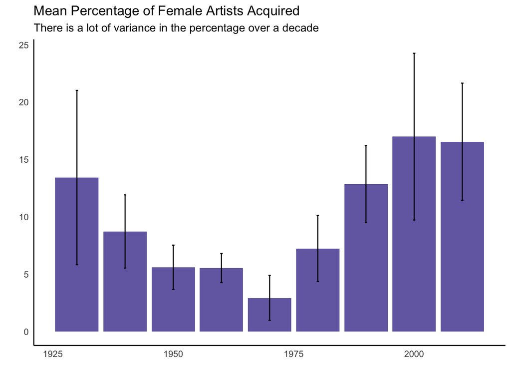

```r
#Graphing the relationship of the percentage of Female artists acquired by the decade.
# 90% CI, get z-value for upper tail, use .95 since is one sided
z <- qnorm(.95)

# Incorporate CI into bar graph of mean percentages of Female artists acquired.
tate_hyp %>%
  filter(decade > 1920) %>%
  group_by(decade, Gender) %>%

  summarise(m = mean(percent), sd = sd(percent),
            n = n(), ci = z * sd/sqrt(n)) %>%
  ggplot(aes(x = decade, y = m)) +
  geom_bar(stat = "identity", fill = "#756bb1") +
  geom_errorbar(aes(ymin = m - ci, ymax = m + ci),
                width = 0.5, position = position_dodge(0.9)) +
  theme_classic() +
  xlab("") +
  ylab("") +
  theme(axis.ticks.x = element_blank(),
          axis.title.x = element_blank(),
          axis.ticks.y = element_blank()) +
  ggtitle("Mean Percentage of Female Artists Acquired",
          subtitle = "There is a lot of variance in the percentage over a decade")
```

- Graph with error bar, we can see the relationship we say in the t-tests.
- There are large error bars on some decades suggesting that we cannot determine if there was a true difference in the percentages or not.
- We can only observe most statistical differences in the long-term, mainly from the lows of the 1970’s.

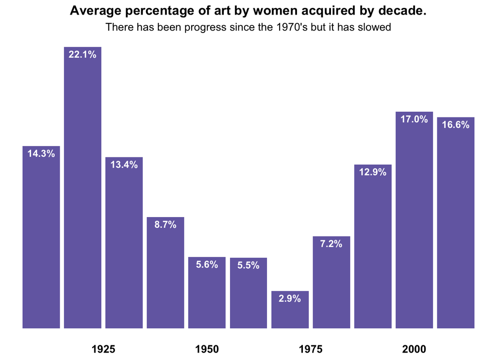

```r
#Graphing the relationship above without error bars.
tate_g2 <-tate_hyp %>%
  group_by(decade, Gender) %>%
  summarise(m = mean(percent), sd = sd(percent),
            n = n(), ci = z * sd/sqrt(n)) %>%
  ggplot(aes(x = decade, y = m)) +
  geom_bar(stat = "identity", fill = "#756bb1") +
  geom_text(aes(label = percent(m/100)), vjust=1.5, color = "white", fontface = 2,
           position = position_dodge(0.9), size = 3.5)+
  theme_void() +
  theme(axis.text.x = element_text(face = "bold", size = 11),
        axis.title = element_blank(),
        axis.ticks.x = element_blank(),
        axis.line.x = element_blank(),
        legend.position = "right",
        legend.title = element_text(face = "bold"),
        plot.title = element_text(hjust=0.5, face ="bold"),
        plot.subtitle = element_text(hjust = 0.5)) +
  ggtitle("Average percentage of art by women acquired by decade.",
          subtitle = "There has been progress since the 1970's but it has slowed")

tate_g2
```

```r
ggsave("tate_g2.png", plot = tate_g2)
```

## 6.2 Conclusion

In addressing the main research question, we had to first determine that gender inequality does exist in the Tate collection. After gender inequality was identified we could examine the acquisition patterns of the Tate in order to determine if they were making progress; i.e. acquiring a higher ratio of female artists. Based on the detailed EDA and statistical analysis it is shown that some progress is being made in terms of the ratio of women artists being acquired by the Tate. However, there is not particularly strong statistical evidence for this progress. The numbers show only a meek improvement of the ratio on average over the decades. It is easy to see a significant difference between the lows of the 1970’s and the 2010’s but progress is far more difficult to quantify in the 2000’s. The recommendation of this study is that the Tate should be pushed by patrons to acquire more art by female artists, particularly female British artists. The Tate claims to watch to “reflect the diversity of their community”, the first step will be closing the gender gap that currently exists. As a charitable organization, Tate members have a voice and they should use data driven activism within the ranks to spur progress.